# Latihan Simulasi Model Data Deret Waktu

Muhammad Luthfi Al Gifari

2023-09-21

## Pembangkitan Proses MA(2)

Akan dicoba membangkitkan proses MA, yaitu MA(2) dengan $\theta_1 = 0.4$ dan $\theta_2 = 0.6$ sebanyak 300 observasi dan $c=0$. Karena diperlukan satu nilai awal untuk $e_{t-1}$ dan $e_{t-2}$, masukkan nilai pertama white noise sebagai nilai awal tersebut.

```r
# Soal Nomor 1
set.seed(031)
wn <- rnorm(300)
wn
```

```
##   [1]  0.055570243 -0.184238585  1.595761833  0.964835923  1.506266908
##   [6] -0.444723576  0.390367317  0.919197137 -1.274471402 -0.730809649
##  [11] -1.068967530 -0.336218010  0.171398839 -1.047110814 -0.990412415
##  [16] -0.917538036 -0.046560892  0.856379168  0.033318462 -0.922549821
##  [21] -1.645876016 -0.201580519  0.619791548  0.758830681 -0.118846325
##  [26]  0.075410938  2.341438341  0.017511502 -0.186372898 -0.041911647
##  [31] -1.289745405  0.808757845  0.736146760 -1.015865586  0.081296518
##  [36] -0.136506590 -1.525641726 -1.131409475 -0.639575808 -1.466663587
##  [41] -0.062296985  0.306470564 -1.791133463  0.445965068 -0.752850071
##  [46] -0.033578441 -0.233755215 -2.540767663  0.517229256 -0.119026616
##  [51]  1.363553156  1.433416408 -0.850111279  1.565815891 -0.022730098
##  [56] -0.945675356 -0.092203678  0.845230791 -1.366592612 -0.726625944
##  [61]  1.115426597 -0.686002575  0.089055094 -0.599953501 -1.250801653
##  [66] -1.483331345  0.199776569 -0.021561602  0.817606853  0.557511843
##  [71]  0.765623838 -0.413472512  0.088756405 -1.420899142 -0.192713462
```

[output cut: 45 more lines]

```r
ma <- wn[c(1:2)]
ma
```

```
## [1]  0.05557024 -0.18423859
```

Nilai-nilai selanjutnya dapat dicari melalui *loop*. Bentuk loop dapat dilihat dari rumus MA(2) yang hendak dibangkitkan:

```r
for(i in 3:300){
   ma[i] <- wn[i] + 0.4 * wn[i - 1] + 0.6 * wn[i - 2]
}
ma
```

```
##   [1]  0.055570243 -0.184238585  1.555408544  1.492597505  2.849658377
##   [6]  0.736684741  1.116238031  0.808509918 -0.672572157 -0.689079928
##  [11] -2.125974231 -1.202290812 -0.604468883 -1.180282084 -1.306417437
##  [16] -1.941969490 -1.007823555  0.287231990  0.347933594 -0.395394935
##  [21] -1.994904868 -1.413460818 -0.448366269  0.885798989  0.556560877
##  [26]  0.483170817  2.300294922  0.999333402  1.225494707 -0.105953905
##  [31] -1.418333803  0.267712695  0.285802655 -0.236152176  0.116638339
##  [36] -0.713507334 -1.531466451 -1.823570119 -2.007524634 -2.401339595
##  [41] -1.032707905 -0.598446382 -1.705923429 -0.086605979 -1.649144122
##  [46] -0.067139429 -0.698896634 -2.654416813 -0.639330938 -1.436595511
##  [51]  1.626280063  1.907421701  0.541387178  2.085821224  0.093529491
##  [56] -0.015277861 -0.484111880  0.240944106 -1.083822503 -0.766124515
##  [61]  0.004820652 -0.675807503  0.483910023 -0.975933009 -1.437349997
##  [66] -2.343624107 -1.144036961 -0.831649781  0.928848153  0.871617623
##  [71]  1.479192686  0.227284128  0.382741703 -1.633480087 -0.707819276
```

[output cut: 45 more lines]

Selain menggunakan cara di atas, pembangkitan proses MA(2) dapat dilakukan dengan fungsi `arima.sim()` sebagai berikut.

```r
ma2 <- arima.sim(list(order = c(0, 0, 2), ma = c(0.4, 0.6)), n = 300)
ma2
```

```
## Time Series:
## Start = 1
## End = 300
## Frequency = 1
##   [1]  0.156844391  1.487334080 -1.165245856 -0.119720445 -0.594935747
##   [6]  1.248197517 -0.609125544  0.593322961 -1.437249700  0.285745210
##  [11] -0.120088018  0.517996849  0.473985573 -0.344869566 -1.082107222
##  [16]  0.291257353 -0.209471224  0.266291365  0.940611228  1.617076040
##  [21]  2.550138239  1.811352834 -1.543128098 -0.926313450 -1.982915989
##  [26] -1.040211448 -1.050831283 -0.844727190  0.657744283  2.440542663
##  [31]  1.428721308  1.116166762 -0.275431016  0.694322363  1.918446821
##  [36]  1.158331649  1.536890410  0.984526186  1.199199246  2.094782738
##  [41]  0.362754492 -0.027184557  0.477304989  0.528321912  0.435000039
##  [46] -1.449066030  0.133087023  0.552953356  1.611238572  0.061104810
##  [51] -2.340805112 -1.076331583 -0.797645820  0.499988710  0.599788224
```

[output cut: 49 more lines]

## Karakteristik MA(2)

### Plot Time Series

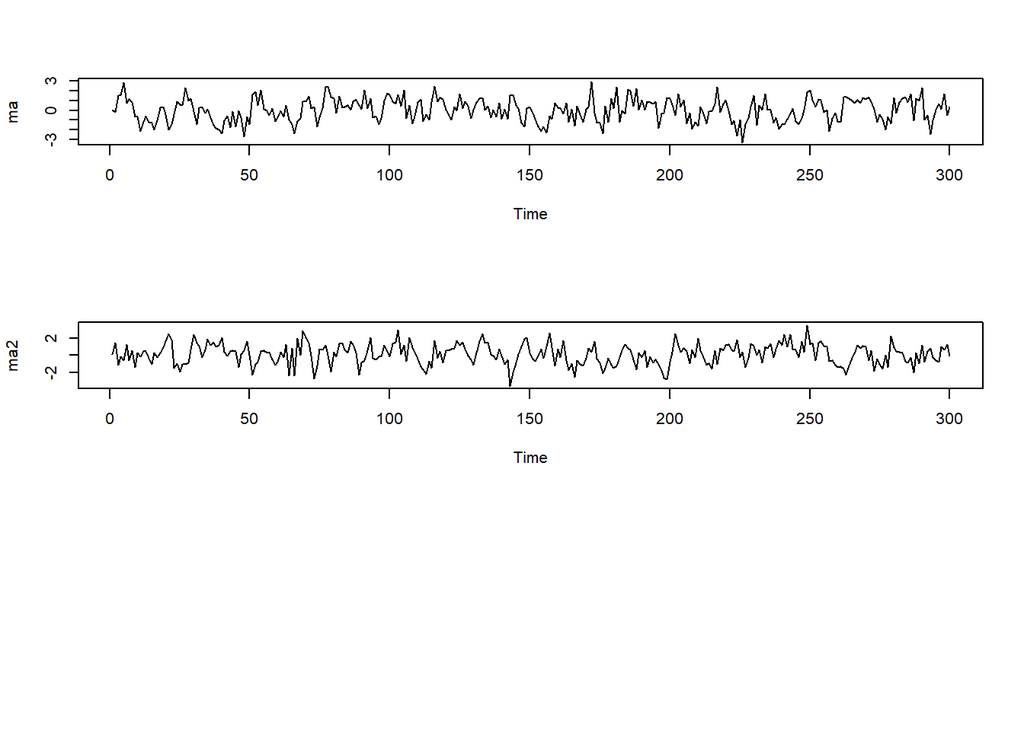

```r
par(mfrow = c(3, 1))
ts.plot(ma)
ts.plot(ma2)
```

### Plot ACF

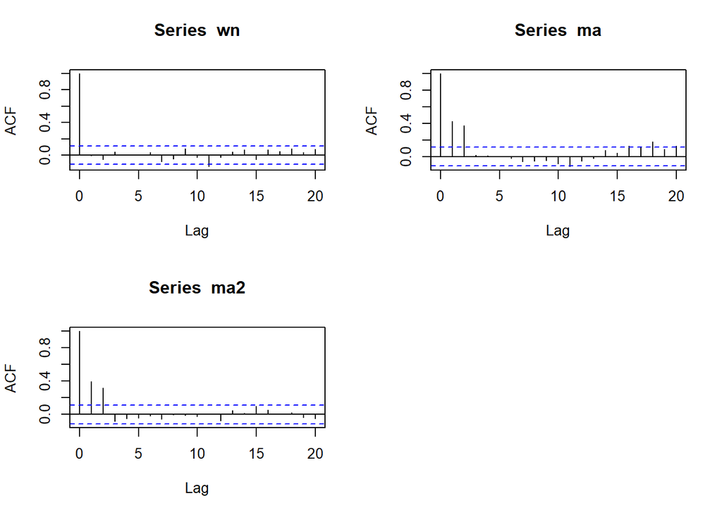

```r
par(mfrow = c(2, 2))
acf(wn, lag.max = 20)
acf(ma, lag.max = 20)
acf(ma2, lag.max = 20)
```

### Plot PACF

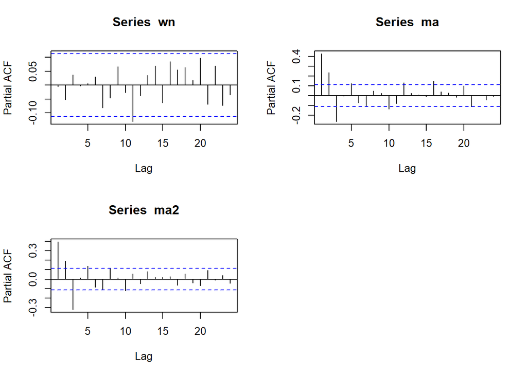

```r
par(mfrow = c(2, 2))
pacf(wn)
pacf(ma)
pacf(ma2)
```

### Plot EACF

```r
TSA::eacf(wn)
```

```
## AR/MA
##   0 1 2 3 4 5 6 7 8 9 10 11 12 13
## 0 o o o o o o o o o o x  o  o  o
## 1 o o o o o o o o o o x  o  o  o
## 2 x x o o o o o o o o o  o  o  o
## 3 o x o o o o o o o o o  o  o  o
## 4 x o o x o o o o o o o  o  o  o
## 5 x o o x x o o o o o o  o  o  o
## 6 x x o x x o o o o o o  o  o  o
## 7 x x x x x o x o o o o  o  o  o
```

```r
TSA::eacf(ma)
```

```
## AR/MA
##   0 1 2 3 4 5 6 7 8 9 10 11 12 13
## 0 x x o o o o o o o o x  o  o  o
## 1 x x x o o o o o o o o  o  o  o
## 2 x x o o o o o o o o o  o  o  o
## 3 o x o o o o o o o o o  o  o  o
## 4 o x x o o o o o o o o  o  o  o
## 5 x x x o o o x o o o o  o  o  o
## 6 x x x o o o x o o o o  o  o  o
## 7 x x x x o o o o o o o  o  o  o
```

```r
TSA::eacf(ma2)
```

```
## AR/MA
##   0 1 2 3 4 5 6 7 8 9 10 11 12 13
## 0 x x o o o o o o o o o  o  o  o
## 1 x x x o o o o o o o o  o  o  o
## 2 x x x x o o o o o o o  o  o  o
## 3 o x x o o o o o o o o  o  o  o
## 4 x x x x x o o o o o o  o  o  o
## 5 x x o x o o o o o o o  o  o  o
## 6 x x x x o o o o o o o  o  o  o
## 7 x x x x o o x o o o o  o  o  o
```

Berdasarkan pola segitiga nol pada plot EACF, terlihat bahwa segitiga nol berada pada ordo AR(0) dan ordo MA(2)

### Scatterplot Antar Lag

#### Korelasi antara $Y_t$ dengan $Y_{t-1}$

```r
# Yt
yt_ma <- ma[-1]
yt_ma
```

```
##   [1] -0.184238585  1.555408544  1.492597505  2.849658377  0.736684741
##   [6]  1.116238031  0.808509918 -0.672572157 -0.689079928 -2.125974231
##  [11] -1.202290812 -0.604468883 -1.180282084 -1.306417437 -1.941969490
##  [16] -1.007823555  0.287231990  0.347933594 -0.395394935 -1.994904868
##  [21] -1.413460818 -0.448366269  0.885798989  0.556560877  0.483170817
##  [26]  2.300294922  0.999333402  1.225494707 -0.105953905 -1.418333803
##  [31]  0.267712695  0.285802655 -0.236152176  0.116638339 -0.713507334
##  [36] -1.531466451 -1.823570119 -2.007524634 -2.401339595 -1.032707905
##  [41] -0.598446382 -1.705923429 -0.086605979 -1.649144122 -0.067139429
##  [46] -0.698896634 -2.654416813 -0.639330938 -1.436595511  1.626280063
##  [51]  1.907421701  0.541387178  2.085821224  0.093529491 -0.015277861
##  [56] -0.484111880  0.240944106 -1.083822503 -0.766124515  0.004820652
##  [61] -0.675807503  0.483910023 -0.975933009 -1.437349997 -2.343624107
##  [66] -1.144036961 -0.831649781  0.928848153  0.871617623  1.479192686
##  [71]  0.227284128  0.382741703 -1.633480087 -0.707819276  0.176839516
```

[output cut: 45 more lines]

```r
head(yt_ma)
```

```
## [1] -0.1842386  1.5554085  1.4925975  2.8496584  0.7366847  1.1162380
```

```r
# Yt-1
yt_1_ma <- ma[-300]
yt_1_ma
```

```
##   [1]  0.055570243 -0.184238585  1.555408544  1.492597505  2.849658377
##   [6]  0.736684741  1.116238031  0.808509918 -0.672572157 -0.689079928
##  [11] -2.125974231 -1.202290812 -0.604468883 -1.180282084 -1.306417437
##  [16] -1.941969490 -1.007823555  0.287231990  0.347933594 -0.395394935
##  [21] -1.994904868 -1.413460818 -0.448366269  0.885798989  0.556560877
##  [26]  0.483170817  2.300294922  0.999333402  1.225494707 -0.105953905
##  [31] -1.418333803  0.267712695  0.285802655 -0.236152176  0.116638339
##  [36] -0.713507334 -1.531466451 -1.823570119 -2.007524634 -2.401339595
##  [41] -1.032707905 -0.598446382 -1.705923429 -0.086605979 -1.649144122
##  [46] -0.067139429 -0.698896634 -2.654416813 -0.639330938 -1.436595511
##  [51]  1.626280063  1.907421701  0.541387178  2.085821224  0.093529491
##  [56] -0.015277861 -0.484111880  0.240944106 -1.083822503 -0.766124515
##  [61]  0.004820652 -0.675807503  0.483910023 -0.975933009 -1.437349997
##  [66] -2.343624107 -1.144036961 -0.831649781  0.928848153  0.871617623
##  [71]  1.479192686  0.227284128  0.382741703 -1.633480087 -0.707819276
```

[output cut: 45 more lines]

```r
head(yt_1_ma)
```

```
## [1]  0.05557024 -0.18423859  1.55540854  1.49259750  2.84965838  0.73668474
```

```r
# Yt
yt_ma2 <- ma2[-1]
yt_ma2
```

```
##   [1]  1.487334080 -1.165245856 -0.119720445 -0.594935747  1.248197517
##   [6] -0.609125544  0.593322961 -1.437249700  0.285745210 -0.120088018
##  [11]  0.517996849  0.473985573 -0.344869566 -1.082107222  0.291257353
##  [16] -0.209471224  0.266291365  0.940611228  1.617076040  2.550138239
##  [21]  1.811352834 -1.543128098 -0.926313450 -1.982915989 -1.040211448
##  [26] -1.050831283 -0.844727190  0.657744283  2.440542663  1.428721308
##  [31]  1.116166762 -0.275431016  0.694322363  1.918446821  1.158331649
##  [36]  1.536890410  0.984526186  1.199199246  2.094782738  0.362754492
##  [41] -0.027184557  0.477304989  0.528321912  0.435000039 -1.449066030
##  [46]  0.133087023  0.552953356  1.611238572  0.061104810 -2.340805112
##  [51] -1.076331583 -0.797645820  0.499988710  0.599788224  0.323128102
##  [56]  0.365657489 -0.495724106 -1.176321193 -0.753835212  0.352759404
##  [61] -0.221741124  1.253987768 -2.359410065  0.857688528 -2.397290204
##  [66]  2.028115881  0.043678428  2.900799111  2.132480675  1.427173074
##  [71] -0.024392565 -2.791776725 -1.275495355  0.779234998  0.661277681
```

[output cut: 45 more lines]

```r
head(yt_ma2)
```

```
## [1]  1.4873341 -1.1652459 -0.1197204 -0.5949357  1.2481975 -0.6091255
```

```r
# Yt-1
yt_1_ma2 <- ma2[-300]
yt_1_ma2
```

```
##   [1]  0.156844391  1.487334080 -1.165245856 -0.119720445 -0.594935747
##   [6]  1.248197517 -0.609125544  0.593322961 -1.437249700  0.285745210
##  [11] -0.120088018  0.517996849  0.473985573 -0.344869566 -1.082107222
##  [16]  0.291257353 -0.209471224  0.266291365  0.940611228  1.617076040
##  [21]  2.550138239  1.811352834 -1.543128098 -0.926313450 -1.982915989
##  [26] -1.040211448 -1.050831283 -0.844727190  0.657744283  2.440542663
##  [31]  1.428721308  1.116166762 -0.275431016  0.694322363  1.918446821
##  [36]  1.158331649  1.536890410  0.984526186  1.199199246  2.094782738
##  [41]  0.362754492 -0.027184557  0.477304989  0.528321912  0.435000039
##  [46] -1.449066030  0.133087023  0.552953356  1.611238572  0.061104810
##  [51] -2.340805112 -1.076331583 -0.797645820  0.499988710  0.599788224
##  [56]  0.323128102  0.365657489 -0.495724106 -1.176321193 -0.753835212
##  [61]  0.352759404 -0.221741124  1.253987768 -2.359410065  0.857688528
##  [66] -2.397290204  2.028115881  0.043678428  2.900799111  2.132480675
##  [71]  1.427173074 -0.024392565 -2.791776725 -1.275495355  0.779234998
```

[output cut: 45 more lines]

```r
head(yt_1_ma2)
```

```
## [1]  0.1568444  1.4873341 -1.1652459 -0.1197204 -0.5949357  1.2481975
```

**Scatter Plot Hubungan Y dan X**

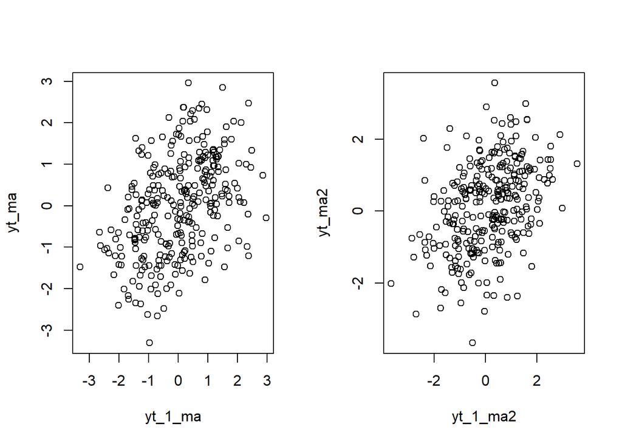

```r
par(mfrow = c(1, 2))
plot(y = yt_ma, x = yt_1_ma)
plot(y = yt_ma2, x = yt_1_ma2)
```

**Nilai Korelasi**

```r
cor(yt_ma, yt_1_ma)
```

```
## [1] 0.4263483
```

```r
cor(yt_ma2, yt_1_ma2)
```

```
## [1] 0.394479
```

#### Korelasi antara $Y_t$ dengan $Y_{t-2}$

```r
# Yt
yt2_ma <- ma[-c(1, 2)]
head(yt2_ma)
```

```
## [1] 1.5554085 1.4925975 2.8496584 0.7366847 1.1162380 0.8085099
```

```r
# Yt-1
yt2_1_ma <- ma[-c(299, 300)]
head(yt2_1_ma)
```

```
## [1]  0.05557024 -0.18423859  1.55540854  1.49259750  2.84965838  0.73668474
```

```r
# Yt
yt2_ma2 <- ma2[-c(1, 2)]
head(yt2_ma2)
```

```
## [1] -1.1652459 -0.1197204 -0.5949357  1.2481975 -0.6091255  0.5933230
```

```r
# Yt-1
yt2_1_ma2 <- ma2[-c(299, 300)]
head(yt2_1_ma2)
```

```
## [1]  0.1568444  1.4873341 -1.1652459 -0.1197204 -0.5949357  1.2481975
```

**Scatter Plot Hubungan Y dan X**

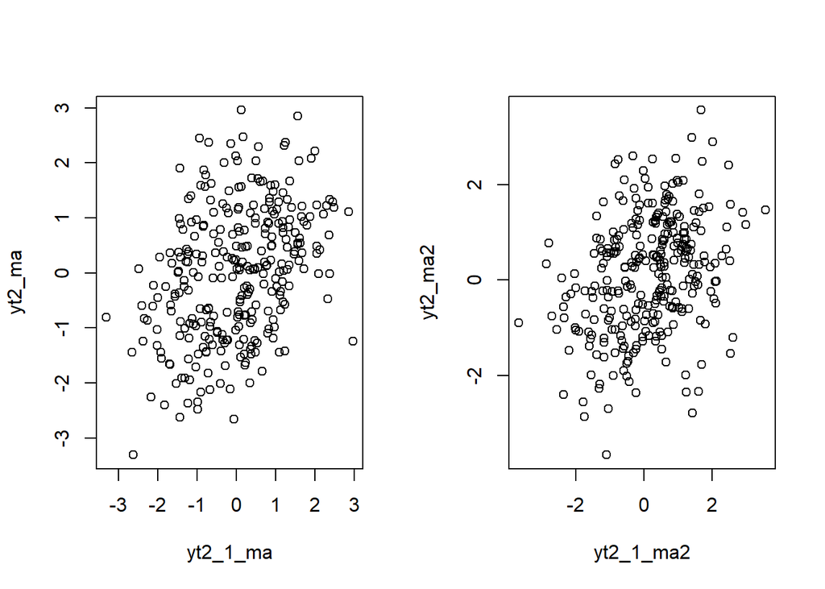

```r
par(mfrow = c(1, 2))
plot(y = yt2_ma, x = yt2_1_ma)
plot(y = yt2_ma2, x = yt2_1_ma2)
```

**Nilai Korelasi**

```r
cor(yt2_ma, yt2_1_ma)
```

```
## [1] 0.373174
```

```r
cor(yt2_ma2, yt2_1_ma2)
```

```
## [1] 0.3201883
```

#### Korelasi antara $Y_t$ dengan $Y_{t-3}$

```r
# Yt
yt3_ma <- ma[-c(1, 2, 3)]
head(yt3_ma)
```

```
## [1]  1.4925975  2.8496584  0.7366847  1.1162380  0.8085099 -0.6725722
```

```r
# Yt-1
yt3_1_ma <- ma[-c(298, 299, 300)]
head(yt3_1_ma)
```

```
## [1]  0.05557024 -0.18423859  1.55540854  1.49259750  2.84965838  0.73668474
```

```r
# Yt
yt3_ma2 <- ma2[-c(1, 2, 3)]
head(yt3_ma2)
```

```
## [1] -0.1197204 -0.5949357  1.2481975 -0.6091255  0.5933230 -1.4372497
```

```r
# Yt-1
yt3_1_ma2 <- ma2[-c(298, 299, 300)]
head(yt3_1_ma2)
```

```
## [1]  0.1568444  1.4873341 -1.1652459 -0.1197204 -0.5949357  1.2481975
```

**Plot Hubungan Y dan X**

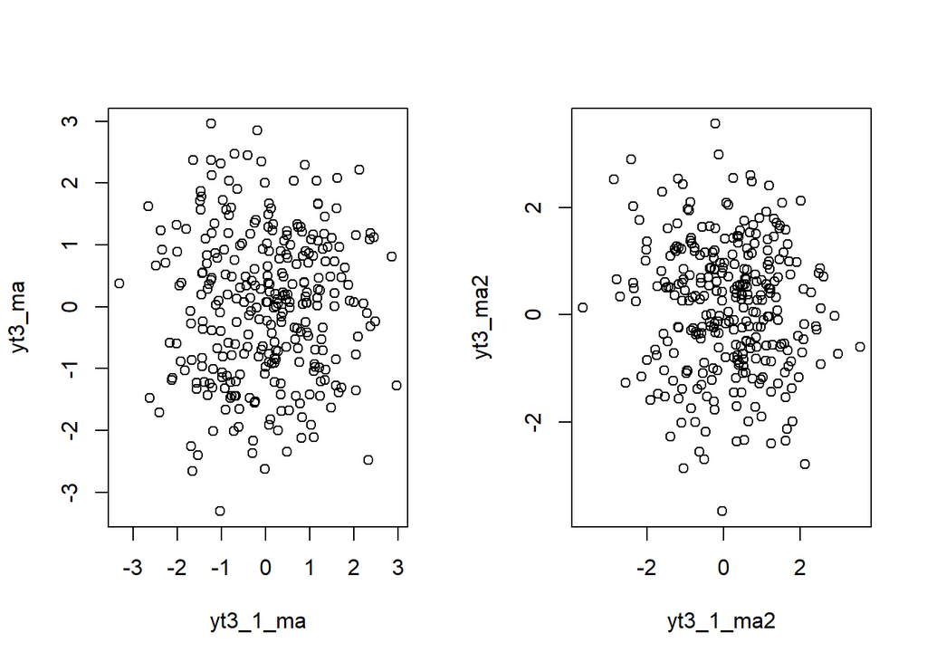

```r
par(mfrow = c(1, 2))
plot(y = yt3_ma, x = yt3_1_ma)
plot(y = yt3_ma2, x = yt3_1_ma2)
```

**Nilai Korelasi**

```r
cor(yt3_ma, yt3_1_ma)
```

```
## [1] 0.01711564
```

```r
cor(yt3_ma2, yt3_1_ma2)
```

```
## [1] -0.0822167
```

## Pembangkitan Proses AR(2)

Akan dicoba membangkitkan proses AR, yaitu AR(2) sebanyak 300 observasi.

```r
# Soal Nomor 2
set.seed(031)
```

Nilai-nilai selanjutnya dapat dicari melalui *loop*. Bentuk loop dapat dilihat dari rumus AR(2) yang hendak dibangkitkan:

```r
n <- length(wn)
n
```

```
## [1] 300
```

```r
ar <- c(1:n)
for (i in 3:n) {ar[i] <- wn[i] + 0.5*ar[i-1] + 0.2*ar[i-2]}
ar
```

```
##   [1]  1.000000000  2.000000000  2.795761833  2.762716839  3.446777695
##   [6]  1.831208639  1.995327175  2.283102452  0.266145259 -0.141116529
##  [11] -1.086296743 -0.907589687 -0.499655353 -1.478456428 -1.829571699
##  [16] -2.128015171 -1.476482817 -0.307465275 -0.415710739 -1.191898245
##  [21] -2.324967287 -1.602443812 -0.646423815  0.115130011 -0.190566082
##  [26]  0.003153900  2.304902074  1.170593319  0.859904176  0.622159105
##  [31] -0.806685017  0.529847157  0.839733335 -0.490029488  0.004228441
##  [36] -0.232398267 -1.640995171 -1.998386714 -1.966968199 -2.849825029
##  [41] -1.880603140 -1.203796012 -2.769152097 -1.179370183 -1.896365582
##  [46] -1.217635269 -1.221845965 -3.395217699 -1.424748787 -1.510444549
##  [51]  0.323381124  1.293018060 -0.138926024  1.754956491  0.826962942
##  [56] -0.181202586 -0.017412383  0.800284082 -0.969933048 -1.051535652
##  [61]  0.395672161 -0.698473625 -0.181047286 -0.830171869 -1.702097044
##  [66] -2.500414241 -1.390849960 -1.217069430 -0.069097855  0.279549029
##  [71]  0.891578781  0.088226684  0.311185503 -1.247661053 -0.754306888
```

[output cut: 45 more lines]

Selain menggunakan cara di atas, pembangkitan proses AR dapat dilakukan dengan fungsi `arima.sim()` sebagai berikut.

```r
ar2 <- arima.sim(list(order = c(2, 0, 0), ar = c(0.5, 0.2)), n = 300)
ar2
```

```
## Time Series:
## Start = 1
## End = 300
## Frequency = 1
##   [1]  0.0004980406  2.3028773868  1.1690498037  0.8587274808  0.6212620543
##   [6] -0.8073688818  0.5293258146  0.8393358907 -0.4903324781  0.0039974571
##  [11] -0.2325743567 -1.6411294125 -1.9984890525 -1.9670462170 -2.8498845059
##  [16] -1.8806484815 -1.2038305782 -2.7691784485 -1.1793902718 -1.8963808969
##  [21] -1.2176469437 -1.2218548659 -3.3952244846 -1.4247539599 -1.5104484926
##  [26]  0.3233781178  1.2930157687 -0.1389277707  1.7549551589  0.8269619270
##  [31] -0.1812033606 -0.0174129733  0.8002836317 -0.9699333911 -1.0515359137
##  [36]  0.3956719618 -0.6984737770 -0.1810474017 -0.8301719576 -1.7020971118
##  [41] -2.5004142924 -1.3908499995 -1.2170694598 -0.0690978773  0.2795490121
##  [46]  0.8915787682  0.0882266740  0.3111854957 -1.2476610593 -0.7543068926
##  [51]  0.4797787283  2.1351747290  2.1534586925  1.2187267517  1.7528272088
```

[output cut: 49 more lines]

## Karakteristik AR(2)

### Plot Time Series

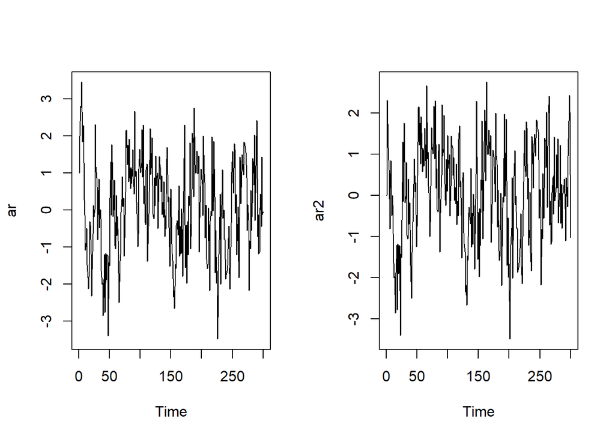

```r
par(mfrow = c(1, 2))
ts.plot(ar)
ts.plot(ar2)
```

Berdasarkan plot time series tersebut terlihat bahwa data cenderung stasioner pada rataan.

### Plot ACF

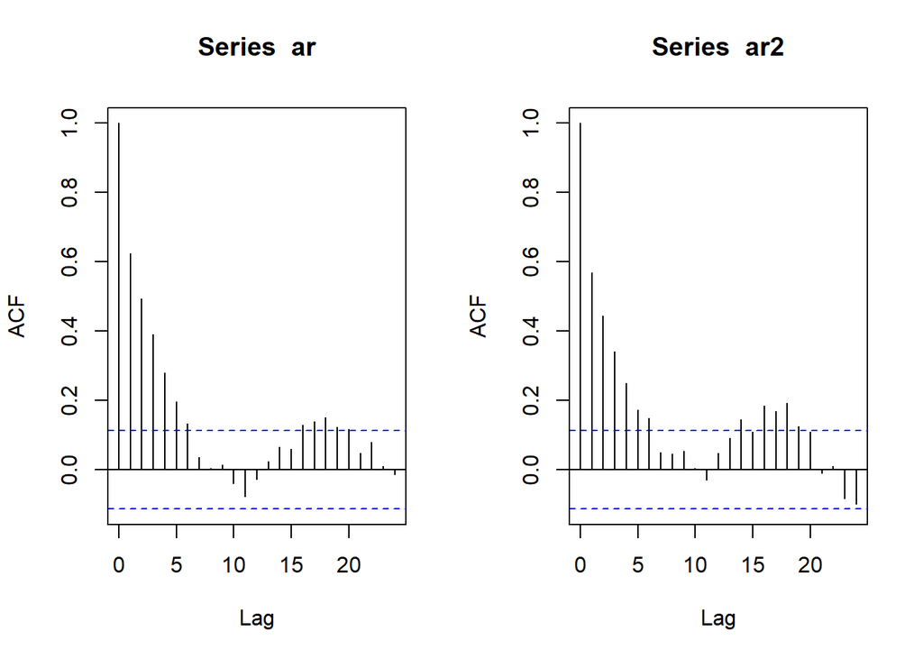

```r
par(mfrow = c(1, 2))
acf(ar)
acf(ar2)
```

Berdasarkan plot ACF tersebut terlihat bahwa plot ACF cenderung *tails off* dan cenderung membentuk pola grafik sinus (fluktuatif naik turun).

### Plot PACF

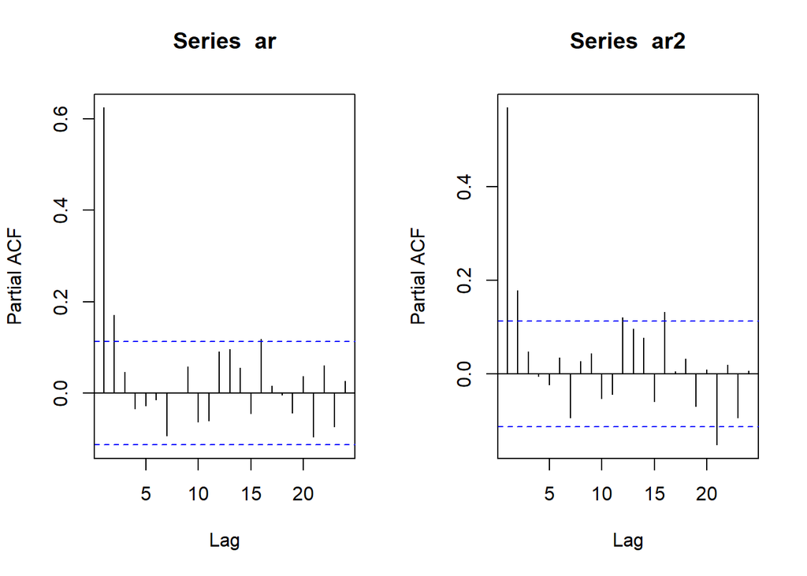

```r
par(mfrow = c(1, 2))
pacf(ar)
pacf(ar2)
```

### Plot EACF

```r
TSA::eacf(ar)
```

```
## AR/MA
##   0 1 2 3 4 5 6 7 8 9 10 11 12 13
## 0 x x x x x x o o o o o  o  o  o
## 1 x o o o o o o o o o o  o  o  o
## 2 x o o o o o o o o o o  o  o  o
## 3 x x o o o o o o o o o  o  o  o
## 4 x o o x o o o o o o o  o  o  o
## 5 x o o x o o o o o o o  o  o  o
## 6 x x x x x o o o o o o  o  o  o
## 7 o x x x o x o o o o o  o  o  o
```

```r
TSA::eacf(ar2)
```

```
## AR/MA
##   0 1 2 3 4 5 6 7 8 9 10 11 12 13
## 0 x x x x x x o o o o o  o  o  x
## 1 x o o o o x o o o o o  o  o  o
## 2 x o o o o o o o o o o  o  o  o
## 3 x x o o o o o o o o o  o  o  o
## 4 x x o o o o o o o o o  o  o  o
## 5 x x o o o o o o o o o  o  o  o
## 6 x x x x x o o o o o o  o  o  o
## 7 x x o x o o o o o o o  o  o  o
```

### Scatterplot Antar Lag

#### Korelasi antara $Y_t$ dengan $Y_{t-1}$

```r
# Yt
yt_ar <- ar[-c(1)]
yt_ar
```

```
##   [1]  2.000000000  2.795761833  2.762716839  3.446777695  1.831208639
##   [6]  1.995327175  2.283102452  0.266145259 -0.141116529 -1.086296743
##  [11] -0.907589687 -0.499655353 -1.478456428 -1.829571699 -2.128015171
##  [16] -1.476482817 -0.307465275 -0.415710739 -1.191898245 -2.324967287
##  [21] -1.602443812 -0.646423815  0.115130011 -0.190566082  0.003153900
##  [26]  2.304902074  1.170593319  0.859904176  0.622159105 -0.806685017
##  [31]  0.529847157  0.839733335 -0.490029488  0.004228441 -0.232398267
##  [36] -1.640995171 -1.998386714 -1.966968199 -2.849825029 -1.880603140
##  [41] -1.203796012 -2.769152097 -1.179370183 -1.896365582 -1.217635269
##  [46] -1.221845965 -3.395217699 -1.424748787 -1.510444549  0.323381124
##  [51]  1.293018060 -0.138926024  1.754956491  0.826962942 -0.181202586
##  [56] -0.017412383  0.800284082 -0.969933048 -1.051535652  0.395672161
##  [61] -0.698473625 -0.181047286 -0.830171869 -1.702097044 -2.500414241
##  [66] -1.390849960 -1.217069430 -0.069097855  0.279549029  0.891578781
##  [71]  0.088226684  0.311185503 -1.247661053 -0.754306888  0.479778732
```

[output cut: 45 more lines]

```r
head(yt_ar)
```

```
## [1] 2.000000 2.795762 2.762717 3.446778 1.831209 1.995327
```

```r
# Yt-1
yt_1_ar <- ar[-c(300)]
yt_1_ar
```

```
##   [1]  1.000000000  2.000000000  2.795761833  2.762716839  3.446777695
##   [6]  1.831208639  1.995327175  2.283102452  0.266145259 -0.141116529
##  [11] -1.086296743 -0.907589687 -0.499655353 -1.478456428 -1.829571699
##  [16] -2.128015171 -1.476482817 -0.307465275 -0.415710739 -1.191898245
##  [21] -2.324967287 -1.602443812 -0.646423815  0.115130011 -0.190566082
##  [26]  0.003153900  2.304902074  1.170593319  0.859904176  0.622159105
##  [31] -0.806685017  0.529847157  0.839733335 -0.490029488  0.004228441
##  [36] -0.232398267 -1.640995171 -1.998386714 -1.966968199 -2.849825029
##  [41] -1.880603140 -1.203796012 -2.769152097 -1.179370183 -1.896365582
##  [46] -1.217635269 -1.221845965 -3.395217699 -1.424748787 -1.510444549
##  [51]  0.323381124  1.293018060 -0.138926024  1.754956491  0.826962942
##  [56] -0.181202586 -0.017412383  0.800284082 -0.969933048 -1.051535652
##  [61]  0.395672161 -0.698473625 -0.181047286 -0.830171869 -1.702097044
##  [66] -2.500414241 -1.390849960 -1.217069430 -0.069097855  0.279549029
##  [71]  0.891578781  0.088226684  0.311185503 -1.247661053 -0.754306888
```

[output cut: 45 more lines]

```r
head(yt_1_ar)
```

```
## [1] 1.000000 2.000000 2.795762 2.762717 3.446778 1.831209
```

```r
# Yt
yt_ar2 <- ar2[-c(1)]
yt_ar2
```

```
##   [1]  2.302877387  1.169049804  0.858727481  0.621262054 -0.807368882
##   [6]  0.529325815  0.839335891 -0.490332478  0.003997457 -0.232574357
##  [11] -1.641129412 -1.998489053 -1.967046217 -2.849884506 -1.880648481
##  [16] -1.203830578 -2.769178448 -1.179390272 -1.896380897 -1.217646944
##  [21] -1.221854866 -3.395224485 -1.424753960 -1.510448493  0.323378118
##  [26]  1.293015769 -0.138927771  1.754955159  0.826961927 -0.181203361
##  [31] -0.017412973  0.800283632 -0.969933391 -1.051535914  0.395671962
##  [36] -0.698473777 -0.181047402 -0.830171958 -1.702097112 -2.500414292
##  [41] -1.390850000 -1.217069460 -0.069097877  0.279549012  0.891578768
##  [46]  0.088226674  0.311185496 -1.247661059 -0.754306893  0.479778728
##  [51]  2.135174729  2.153458692  1.218726752  1.752827209  0.765625576
##  [56]  1.911041916  1.132758963  0.576294572  1.138449378  0.709947065
##  [61]  1.099800446  1.626642915  0.845537233  0.424538176  2.659457724
##  [66]  0.893167842  1.050809046  0.219563536 -0.099607610 -0.993835381
##  [71] -0.649898081  1.107837809  1.637470895  1.177119176  1.004572614
```

[output cut: 45 more lines]

```r
head(yt_ar2)
```

```
## [1]  2.3028774  1.1690498  0.8587275  0.6212621 -0.8073689  0.5293258
```

```r
# Yt-1
yt_1_ar2 <- ar2[-c(300)]
yt_1_ar2
```

```
##   [1]  0.0004980406  2.3028773868  1.1690498037  0.8587274808  0.6212620543
##   [6] -0.8073688818  0.5293258146  0.8393358907 -0.4903324781  0.0039974571
##  [11] -0.2325743567 -1.6411294125 -1.9984890525 -1.9670462170 -2.8498845059
##  [16] -1.8806484815 -1.2038305782 -2.7691784485 -1.1793902718 -1.8963808969
##  [21] -1.2176469437 -1.2218548659 -3.3952244846 -1.4247539599 -1.5104484926
##  [26]  0.3233781178  1.2930157687 -0.1389277707  1.7549551589  0.8269619270
##  [31] -0.1812033606 -0.0174129733  0.8002836317 -0.9699333911 -1.0515359137
##  [36]  0.3956719618 -0.6984737770 -0.1810474017 -0.8301719576 -1.7020971118
##  [41] -2.5004142924 -1.3908499995 -1.2170694598 -0.0690978773  0.2795490121
##  [46]  0.8915787682  0.0882266740  0.3111854957 -1.2476610593 -0.7543068926
##  [51]  0.4797787283  2.1351747290  2.1534586925  1.2187267517  1.7528272088
##  [56]  0.7656255756  1.9110419155  1.1327589632  0.5762945717  1.1384493778
##  [61]  0.7099470649  1.0998004459  1.6266429146  0.8455372332  0.4245381760
##  [66]  2.6594577242  0.8931678422  1.0508090464  0.2195635364 -0.0996076099
##  [71] -0.9938353805 -0.6498980813  1.1078378088  1.6374708947  1.1771191759
```

[output cut: 45 more lines]

```r
head(yt_1_ar2)
```

```
## [1]  0.0004980406  2.3028773868  1.1690498037  0.8587274808  0.6212620543
## [6] -0.8073688818
```

**Scatter Plot Hubungan Y dan X**

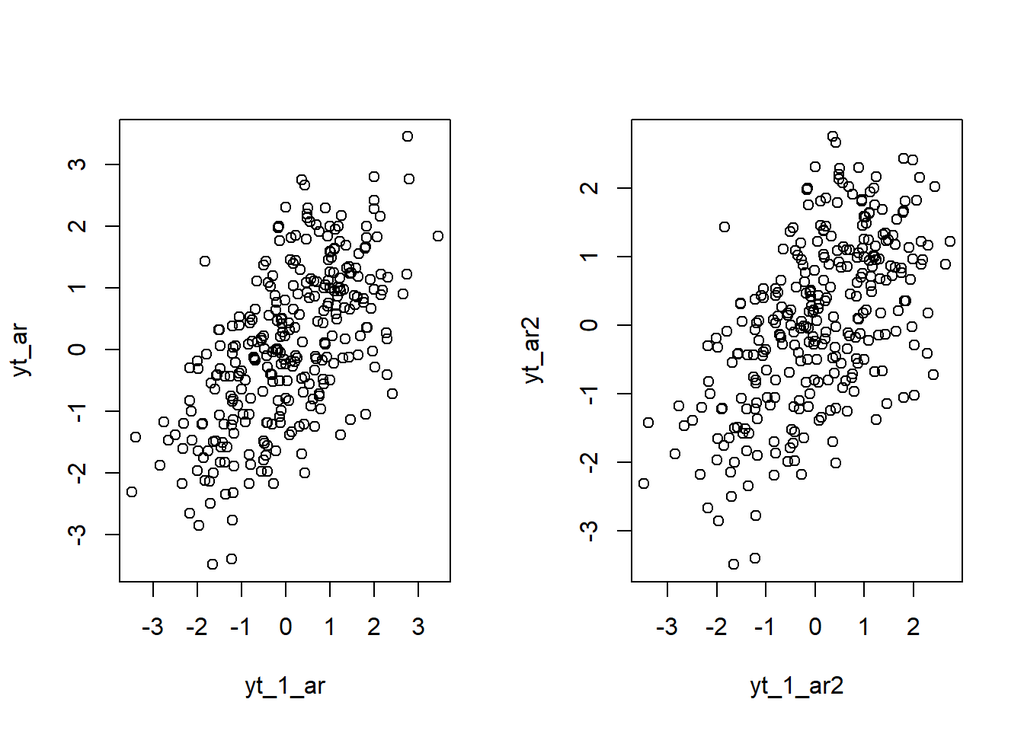

```r
par(mfrow = c(1, 2))
plot(y = yt_ar, x = yt_1_ar)
plot(y = yt_ar2, x = yt_1_ar2)
```

**Nilai Korelasi**

```r
cor(yt_ar, yt_1_ar)
```

```
## [1] 0.6249464
```

```r
cor(yt_ar2, yt_1_ar2)
```

```
## [1] 0.5697337
```

#### Korelasi antara $Y_t$ dengan $Y_{t-2}$

```r
# Yt
yt2_ar <- ar[-c(1, 2)]
yt2_ar
```

```
##   [1]  2.795761833  2.762716839  3.446777695  1.831208639  1.995327175
##   [6]  2.283102452  0.266145259 -0.141116529 -1.086296743 -0.907589687
##  [11] -0.499655353 -1.478456428 -1.829571699 -2.128015171 -1.476482817
##  [16] -0.307465275 -0.415710739 -1.191898245 -2.324967287 -1.602443812
##  [21] -0.646423815  0.115130011 -0.190566082  0.003153900  2.304902074
##  [26]  1.170593319  0.859904176  0.622159105 -0.806685017  0.529847157
##  [31]  0.839733335 -0.490029488  0.004228441 -0.232398267 -1.640995171
##  [36] -1.998386714 -1.966968199 -2.849825029 -1.880603140 -1.203796012
##  [41] -2.769152097 -1.179370183 -1.896365582 -1.217635269 -1.221845965
##  [46] -3.395217699 -1.424748787 -1.510444549  0.323381124  1.293018060
##  [51] -0.138926024  1.754956491  0.826962942 -0.181202586 -0.017412383
##  [56]  0.800284082 -0.969933048 -1.051535652  0.395672161 -0.698473625
##  [61] -0.181047286 -0.830171869 -1.702097044 -2.500414241 -1.390849960
##  [66] -1.217069430 -0.069097855  0.279549029  0.891578781  0.088226684
##  [71]  0.311185503 -1.247661053 -0.754306888  0.479778732  2.135174732
```

[output cut: 45 more lines]

```r
head(yt2_ar)
```

```
## [1] 2.795762 2.762717 3.446778 1.831209 1.995327 2.283102
```

```r
# Yt-1
yt2_1_ar <- ar[-c(299, 300)]
yt2_1_ar
```

```
##   [1]  1.000000000  2.000000000  2.795761833  2.762716839  3.446777695
##   [6]  1.831208639  1.995327175  2.283102452  0.266145259 -0.141116529
##  [11] -1.086296743 -0.907589687 -0.499655353 -1.478456428 -1.829571699
##  [16] -2.128015171 -1.476482817 -0.307465275 -0.415710739 -1.191898245
##  [21] -2.324967287 -1.602443812 -0.646423815  0.115130011 -0.190566082
##  [26]  0.003153900  2.304902074  1.170593319  0.859904176  0.622159105
##  [31] -0.806685017  0.529847157  0.839733335 -0.490029488  0.004228441
##  [36] -0.232398267 -1.640995171 -1.998386714 -1.966968199 -2.849825029
##  [41] -1.880603140 -1.203796012 -2.769152097 -1.179370183 -1.896365582
##  [46] -1.217635269 -1.221845965 -3.395217699 -1.424748787 -1.510444549
##  [51]  0.323381124  1.293018060 -0.138926024  1.754956491  0.826962942
##  [56] -0.181202586 -0.017412383  0.800284082 -0.969933048 -1.051535652
##  [61]  0.395672161 -0.698473625 -0.181047286 -0.830171869 -1.702097044
##  [66] -2.500414241 -1.390849960 -1.217069430 -0.069097855  0.279549029
##  [71]  0.891578781  0.088226684  0.311185503 -1.247661053 -0.754306888
```

[output cut: 45 more lines]

```r
head(yt2_1_ar)
```

```
## [1] 1.000000 2.000000 2.795762 2.762717 3.446778 1.831209
```

```r
# Yt
yt2_ar2 <- ar2[-c(1, 2)]
yt2_ar2
```

```
##   [1]  1.169049804  0.858727481  0.621262054 -0.807368882  0.529325815
##   [6]  0.839335891 -0.490332478  0.003997457 -0.232574357 -1.641129412
##  [11] -1.998489053 -1.967046217 -2.849884506 -1.880648481 -1.203830578
##  [16] -2.769178448 -1.179390272 -1.896380897 -1.217646944 -1.221854866
##  [21] -3.395224485 -1.424753960 -1.510448493  0.323378118  1.293015769
##  [26] -0.138927771  1.754955159  0.826961927 -0.181203361 -0.017412973
##  [31]  0.800283632 -0.969933391 -1.051535914  0.395671962 -0.698473777
##  [36] -0.181047402 -0.830171958 -1.702097112 -2.500414292 -1.390850000
##  [41] -1.217069460 -0.069097877  0.279549012  0.891578768  0.088226674
##  [46]  0.311185496 -1.247661059 -0.754306893  0.479778728  2.135174729
##  [51]  2.153458692  1.218726752  1.752827209  0.765625576  1.911041916
##  [56]  1.132758963  0.576294572  1.138449378  0.709947065  1.099800446
##  [61]  1.626642915  0.845537233  0.424538176  2.659457724  0.893167842
##  [66]  1.050809046  0.219563536 -0.099607610 -0.993835381 -0.649898081
##  [71]  1.107837809  1.637470895  1.177119176  1.004572614  1.253176808
```

[output cut: 45 more lines]

```r
head(yt2_ar2)
```

```
## [1]  1.1690498  0.8587275  0.6212621 -0.8073689  0.5293258  0.8393359
```

```r
# Yt-1
yt2_1_ar2 <- ar2[-c(299, 300)]
yt2_1_ar2
```

```
##   [1]  0.0004980406  2.3028773868  1.1690498037  0.8587274808  0.6212620543
##   [6] -0.8073688818  0.5293258146  0.8393358907 -0.4903324781  0.0039974571
##  [11] -0.2325743567 -1.6411294125 -1.9984890525 -1.9670462170 -2.8498845059
##  [16] -1.8806484815 -1.2038305782 -2.7691784485 -1.1793902718 -1.8963808969
##  [21] -1.2176469437 -1.2218548659 -3.3952244846 -1.4247539599 -1.5104484926
##  [26]  0.3233781178  1.2930157687 -0.1389277707  1.7549551589  0.8269619270
##  [31] -0.1812033606 -0.0174129733  0.8002836317 -0.9699333911 -1.0515359137
##  [36]  0.3956719618 -0.6984737770 -0.1810474017 -0.8301719576 -1.7020971118
##  [41] -2.5004142924 -1.3908499995 -1.2170694598 -0.0690978773  0.2795490121
##  [46]  0.8915787682  0.0882266740  0.3111854957 -1.2476610593 -0.7543068926
##  [51]  0.4797787283  2.1351747290  2.1534586925  1.2187267517  1.7528272088
##  [56]  0.7656255756  1.9110419155  1.1327589632  0.5762945717  1.1384493778
##  [61]  0.7099470649  1.0998004459  1.6266429146  0.8455372332  0.4245381760
##  [66]  2.6594577242  0.8931678422  1.0508090464  0.2195635364 -0.0996076099
##  [71] -0.9938353805 -0.6498980813  1.1078378088  1.6374708947  1.1771191759
```

[output cut: 45 more lines]

```r
head(yt2_1_ar2)
```

```
## [1]  0.0004980406  2.3028773868  1.1690498037  0.8587274808  0.6212620543
## [6] -0.8073688818
```

**Scatter Plot Hubungan Y dan X**

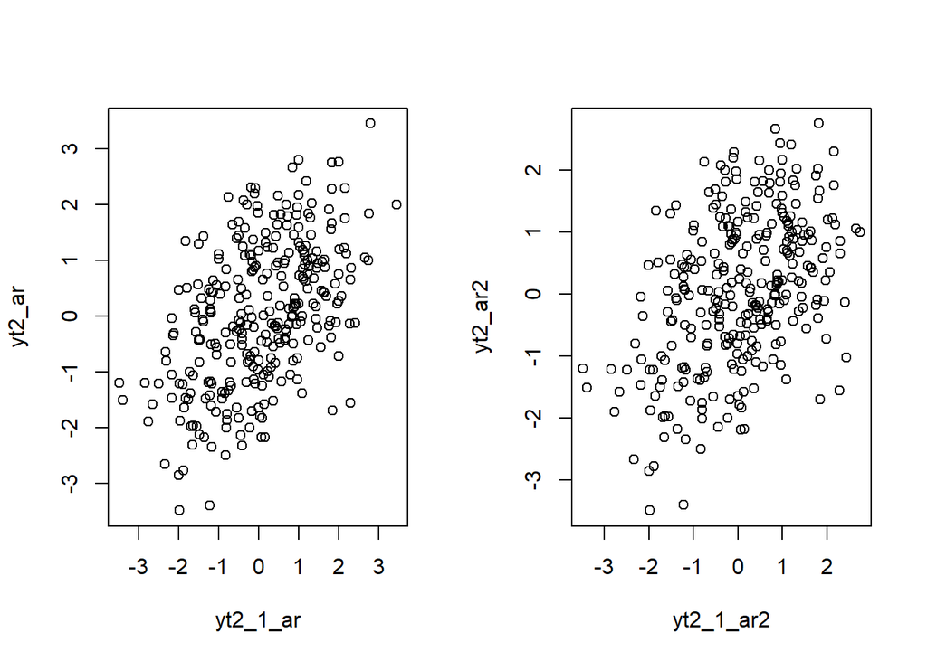

```r
par(mfrow = c(1, 2))
plot(y = yt2_ar, x = yt2_1_ar)
plot(y = yt2_ar2, x = yt2_1_ar2)
```

**Nilai Korelasi**

```r
cor(yt2_ar, yt2_1_ar)
```

```
## [1] 0.4964197
```

```r
cor(yt2_ar2, yt2_1_ar2)
```

```
## [1] 0.4493519
```

#### Korelasi antara $Y_t$ dengan $Y_{t-3}$

```r
# Yt
yt3_ar <- ar[-c(1, 2, 3)]
yt3_ar
```

```
##   [1]  2.762716839  3.446777695  1.831208639  1.995327175  2.283102452
##   [6]  0.266145259 -0.141116529 -1.086296743 -0.907589687 -0.499655353
##  [11] -1.478456428 -1.829571699 -2.128015171 -1.476482817 -0.307465275
##  [16] -0.415710739 -1.191898245 -2.324967287 -1.602443812 -0.646423815
##  [21]  0.115130011 -0.190566082  0.003153900  2.304902074  1.170593319
##  [26]  0.859904176  0.622159105 -0.806685017  0.529847157  0.839733335
##  [31] -0.490029488  0.004228441 -0.232398267 -1.640995171 -1.998386714
##  [36] -1.966968199 -2.849825029 -1.880603140 -1.203796012 -2.769152097
##  [41] -1.179370183 -1.896365582 -1.217635269 -1.221845965 -3.395217699
##  [46] -1.424748787 -1.510444549  0.323381124  1.293018060 -0.138926024
##  [51]  1.754956491  0.826962942 -0.181202586 -0.017412383  0.800284082
##  [56] -0.969933048 -1.051535652  0.395672161 -0.698473625 -0.181047286
##  [61] -0.830171869 -1.702097044 -2.500414241 -1.390849960 -1.217069430
##  [66] -0.069097855  0.279549029  0.891578781  0.088226684  0.311185503
##  [71] -1.247661053 -0.754306888  0.479778732  2.135174732  2.153458694
```

[output cut: 45 more lines]

```r
head(yt3_ar)
```

```
## [1] 2.7627168 3.4467777 1.8312086 1.9953272 2.2831025 0.2661453
```

```r
# Yt-1
yt3_1_ar <- ar[-c(298, 299, 300)]
yt3_1_ar
```

```
##   [1]  1.000000000  2.000000000  2.795761833  2.762716839  3.446777695
##   [6]  1.831208639  1.995327175  2.283102452  0.266145259 -0.141116529
##  [11] -1.086296743 -0.907589687 -0.499655353 -1.478456428 -1.829571699
##  [16] -2.128015171 -1.476482817 -0.307465275 -0.415710739 -1.191898245
##  [21] -2.324967287 -1.602443812 -0.646423815  0.115130011 -0.190566082
##  [26]  0.003153900  2.304902074  1.170593319  0.859904176  0.622159105
##  [31] -0.806685017  0.529847157  0.839733335 -0.490029488  0.004228441
##  [36] -0.232398267 -1.640995171 -1.998386714 -1.966968199 -2.849825029
##  [41] -1.880603140 -1.203796012 -2.769152097 -1.179370183 -1.896365582
##  [46] -1.217635269 -1.221845965 -3.395217699 -1.424748787 -1.510444549
##  [51]  0.323381124  1.293018060 -0.138926024  1.754956491  0.826962942
##  [56] -0.181202586 -0.017412383  0.800284082 -0.969933048 -1.051535652
##  [61]  0.395672161 -0.698473625 -0.181047286 -0.830171869 -1.702097044
##  [66] -2.500414241 -1.390849960 -1.217069430 -0.069097855  0.279549029
##  [71]  0.891578781  0.088226684  0.311185503 -1.247661053 -0.754306888
```

[output cut: 45 more lines]

```r
head(yt3_1_ar)
```

```
## [1] 1.000000 2.000000 2.795762 2.762717 3.446778 1.831209
```

```r
# Yt
yt3_ar2 <- ar2[-c(1, 2, 3)]
yt3_ar2
```

```
##   [1]  0.858727481  0.621262054 -0.807368882  0.529325815  0.839335891
##   [6] -0.490332478  0.003997457 -0.232574357 -1.641129412 -1.998489053
##  [11] -1.967046217 -2.849884506 -1.880648481 -1.203830578 -2.769178448
##  [16] -1.179390272 -1.896380897 -1.217646944 -1.221854866 -3.395224485
##  [21] -1.424753960 -1.510448493  0.323378118  1.293015769 -0.138927771
##  [26]  1.754955159  0.826961927 -0.181203361 -0.017412973  0.800283632
##  [31] -0.969933391 -1.051535914  0.395671962 -0.698473777 -0.181047402
##  [36] -0.830171958 -1.702097112 -2.500414292 -1.390850000 -1.217069460
##  [41] -0.069097877  0.279549012  0.891578768  0.088226674  0.311185496
##  [46] -1.247661059 -0.754306893  0.479778728  2.135174729  2.153458692
##  [51]  1.218726752  1.752827209  0.765625576  1.911041916  1.132758963
##  [56]  0.576294572  1.138449378  0.709947065  1.099800446  1.626642915
##  [61]  0.845537233  0.424538176  2.659457724  0.893167842  1.050809046
##  [66]  0.219563536 -0.099607610 -0.993835381 -0.649898081  1.107837809
##  [71]  1.637470895  1.177119176  1.004572614  1.253176808  2.162983689
```

[output cut: 45 more lines]

```r
head(yt3_ar2)
```

```
## [1]  0.8587275  0.6212621 -0.8073689  0.5293258  0.8393359 -0.4903325
```

```r
# Yt-1
yt3_1_ar2 <- ar2[-c(298, 299, 300)]
yt3_1_ar2
```

```
##   [1]  0.0004980406  2.3028773868  1.1690498037  0.8587274808  0.6212620543
##   [6] -0.8073688818  0.5293258146  0.8393358907 -0.4903324781  0.0039974571
##  [11] -0.2325743567 -1.6411294125 -1.9984890525 -1.9670462170 -2.8498845059
##  [16] -1.8806484815 -1.2038305782 -2.7691784485 -1.1793902718 -1.8963808969
##  [21] -1.2176469437 -1.2218548659 -3.3952244846 -1.4247539599 -1.5104484926
##  [26]  0.3233781178  1.2930157687 -0.1389277707  1.7549551589  0.8269619270
##  [31] -0.1812033606 -0.0174129733  0.8002836317 -0.9699333911 -1.0515359137
##  [36]  0.3956719618 -0.6984737770 -0.1810474017 -0.8301719576 -1.7020971118
##  [41] -2.5004142924 -1.3908499995 -1.2170694598 -0.0690978773  0.2795490121
##  [46]  0.8915787682  0.0882266740  0.3111854957 -1.2476610593 -0.7543068926
##  [51]  0.4797787283  2.1351747290  2.1534586925  1.2187267517  1.7528272088
##  [56]  0.7656255756  1.9110419155  1.1327589632  0.5762945717  1.1384493778
##  [61]  0.7099470649  1.0998004459  1.6266429146  0.8455372332  0.4245381760
##  [66]  2.6594577242  0.8931678422  1.0508090464  0.2195635364 -0.0996076099
##  [71] -0.9938353805 -0.6498980813  1.1078378088  1.6374708947  1.1771191759
```

[output cut: 45 more lines]

```r
head(yt3_1_ar2)
```

```
## [1]  0.0004980406  2.3028773868  1.1690498037  0.8587274808  0.6212620543
## [6] -0.8073688818
```

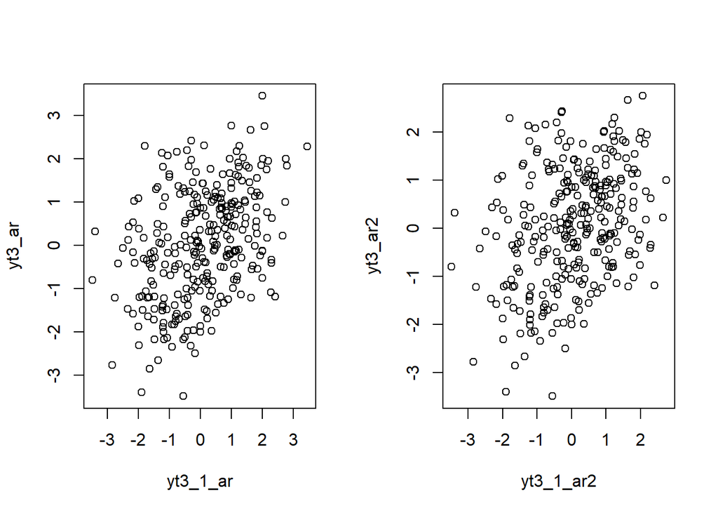

```r
par(mfrow = c(1, 2))
plot(y = yt3_ar, x = yt3_1_ar)
plot(y = yt3_ar2, x = yt3_1_ar2)
```

**Nilai Korelasi**

```r
cor(yt3_ar, yt3_1_ar)
```

```
## [1] 0.3954214
```

```r
cor(yt3_ar2, yt3_1_ar2)
```

```
## [1] 0.347002
```

## Fungsi pembangkitan ARMA (2,2)

```r
# Soal Nomor 3
set.seed(031)
coefs <- c(0.6, 0.4, 0.5, 0.2)
coefs
```

```
## [1] 0.6 0.4 0.5 0.2
```

```r
e <- c(1, 2, 3, 4)
e
```

```
## [1] 1 2 3 4
```

```r
coefs %*% e
```

```
##      [,1]
## [1,]  3.7
```

**Fungsi ‘ARMA.sim’ + Bentuk *Loop***

```r
arma.sim <- function(n, macoef, arcoef){
  manum <- length(macoef)
  arnum <- length(arcoef)
  stopifnot(manum < n & arnum < n)

  wn <- rnorm(n, sd = 0.5)
  init <- max(manum, arnum)

  arma <- wn[1:init]
  for(i in {init+1}:n){
   mastart <- i - manum
   maend <- i-1
   arstart <- i - arnum
   arend <- i-1
   arma[i] <- sum(arcoef * arma[arstart:arend]) + sum(macoef * wn[mastart:maend])  + wn[i]
   }
  return(arma)
}
```

```r
# Contoh untuk ARMA
arma02 <- arma.sim(300, c(0.4, 0.6), c(0.5, 0.2))
arma02
```

```
##   [1]  0.02778512 -0.09211929  0.74919209  1.02807757  1.94194816  1.32491388
##   [7]  1.59897682  1.47001635  0.81008859  0.33311908 -0.53695283 -0.57579222
##  [13] -0.61259435 -0.94979434 -1.27131573 -1.69447522 -1.47117725 -0.91075935
##  [19] -0.65347969 -0.86607915 -1.59299494 -1.53070159 -1.18239137 -0.47679237
##  [25] -0.39436981 -0.16345244  0.93969780  0.83248278  1.01670012  0.54621602
##  [31] -0.07712751  0.26675548  0.36753899  0.08154834  0.08319710 -0.18962387
##  [37] -0.78383976 -1.30227846 -1.61671466 -2.12596859 -1.83261378 -1.58829358
##  [43] -2.05005057 -1.45722030 -1.91733155 -1.26552769 -1.48929247 -2.27784842
##  [49] -1.75058263 -1.90153880 -0.50608463  0.04998250  0.03463410  0.84647591
##  [55]  0.47496969  0.35173837 -0.02651795  0.37638481 -0.38614981 -0.49328215
##  [61] -0.22532435 -0.44540444 -0.13993097 -0.66114915 -0.98977117 -1.76542568
##  [67] -1.44324217 -1.41887537 -0.56310590 -0.30233321  0.37156725  0.05760011
##  [73]  0.27076486 -0.68356413 -0.50620559 -0.23178485  1.01701023  1.41760431
##  [79]  1.35571123  1.44880230  0.94717351  1.53886210  1.07580805  1.04121262
##  [85]  0.95115629  0.83623573  1.03378291  1.25248489  1.05736967  0.80656423
```

[output cut: 35 more lines]

```r
head(arma02)
```

```
## [1]  0.02778512 -0.09211929  0.74919209  1.02807757  1.94194816  1.32491388
```

```r
n = length(wn)
n
```

```
## [1] 300
```

```r
phi1 = 0.5
phi1
```

```
## [1] 0.5
```

```r
phi2 = 0.2
phi2
```

```
## [1] 0.2
```

```r
theta1 = 0.4
theta1
```

```
## [1] 0.4
```

```r
theta2 = 0.6
theta2
```

```
## [1] 0.6
```

```r
y.arma = c(1:n)
for (i in 3:n){y.arma[i] = phi1*y.arma[i-1] + theta1*wn[i-1] + phi2*y.arma[i-2] + theta2*wn[i-2] + wn[i]}
head(y.arma)
```

```
## [1] 1.000000 2.000000 2.755409 3.270302 5.035891 3.908691
```

Pembangkitan ARMA (p, q) juga dapat dilakukan dengan fungsi `arima.sim` sebagai berikut.

```r
arma22 <- arima.sim(list(order = c(2, 0, 2), ar = c(0.5, 0.2), ma = c(0.4, 0.6)), n = 300)
arma22
```

```
## Time Series:
## Start = 1
## End = 300
## Frequency = 1
##   [1] -1.678306556 -2.185986827 -2.273381915 -0.916144040  1.527794260
##   [6]  2.009389630  2.426420429  1.339657124  1.849435011  3.111095751
##  [11]  3.083766526  3.700992823  3.451775903  3.665285762  4.617780800
##  [16]  3.404702044  2.598722625  2.457606710  2.276869792  2.064956277
##  [21]  0.038786067  0.565471311  0.843446225  2.146055947  1.302822028
##  [26] -1.260182908 -1.445858632 -1.772611717 -0.675488875 -0.092478556
##  [31]  0.141791049  0.418057302 -0.258337246 -1.221878356 -1.416441839
##  [36] -0.599837187 -0.804948085  0.731546288 -2.154626538 -0.073315484
##  [41] -2.864873253  0.581016158 -0.238788143  2.897608271  3.533527182
##  [46]  3.773458320  2.569042031 -0.752564045 -1.137968972  0.059737703
##  [51]  0.463552738  1.472821619  0.886583859 -1.250291225 -0.039283211
```

[output cut: 49 more lines]

```r
head(arma22)
```

```
## [1] -1.678307 -2.185987 -2.273382 -0.916144  1.527794  2.009390
```

### Plot Time Series

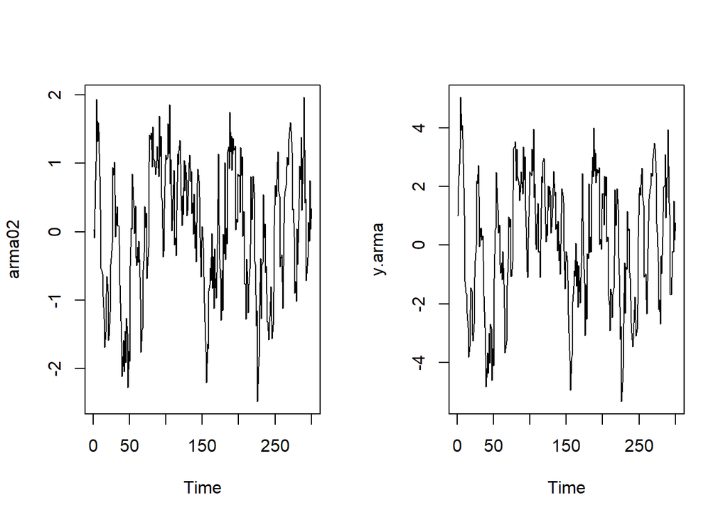

```r
par(mfrow = c(1, 2))
ts.plot(arma02)
ts.plot(y.arma)
```

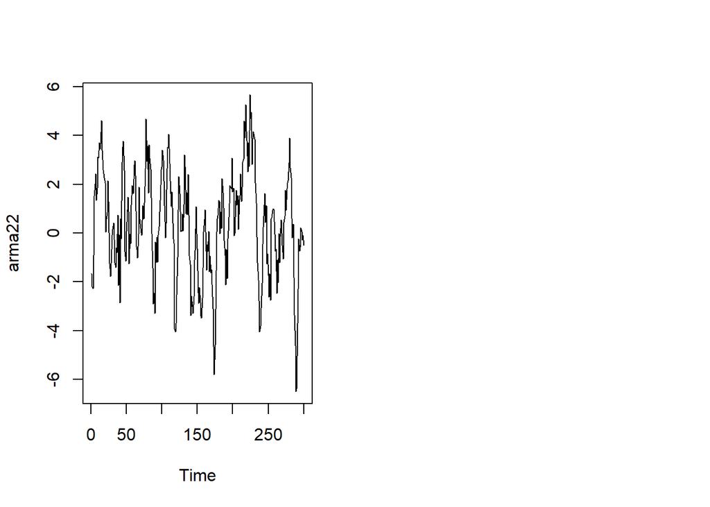

```r
ts.plot(arma22)
par(mfrow = c(1, 1))
```

Berdasarkan plot time series tersebut, terlihat bahwa data arma22 cenderung stasioner dalam rataan.

### Plot ACF

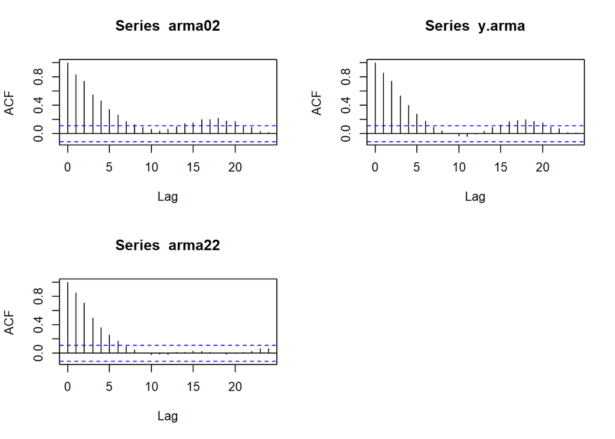

```r
par(mfrow = c(2, 2))
acf(arma02)
acf(y.arma)
acf(arma22)
par(mfrow = c(1, 1))
```

Berdasarkan plot ACF tersebut, terlihat bahwa model ARMA(2,2) hasil simulasi memiliki plot ACF yang *tails off*, sesuai dengan teori yang ada.

### Plot PACF

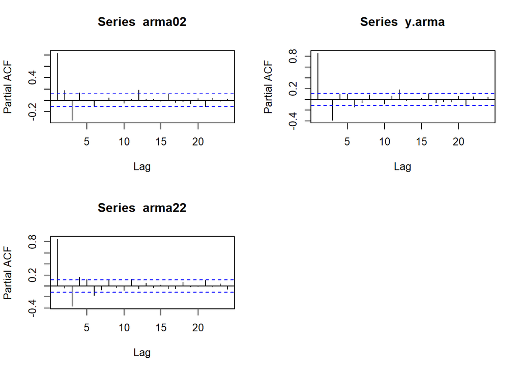

```r
par(mfrow = c(2, 2))
pacf(arma02)
pacf(y.arma)
pacf(arma22)
par(mfrow = c(1, 1))
```

Berdasarkan plot PACF tersebut, terlihat bahwa model ARMA(2,2) hasil simulasi memiliki plot PACF yang *tails off*, sesuai dengan teori.

### Plot EACF

```r
TSA::eacf(arma02)
```

```
## AR/MA
##   0 1 2 3 4 5 6 7 8 9 10 11 12 13
## 0 x x x x x x x x o o o  o  o  x
## 1 x x x x o o o o o o o  o  o  o
## 2 x x o x o o o o o o o  o  o  o
## 3 x o x o o o o o o o o  o  o  o
## 4 o x x o o o o o o o o  o  o  o
## 5 x x o o o o o o o o o  o  o  o
## 6 o x x o o o o o o o o  o  o  o
## 7 x x x x o o o o o o o  o  o  o
```

```r
TSA::eacf(y.arma)
```

```
## AR/MA
##   0 1 2 3 4 5 6 7 8 9 10 11 12 13
## 0 x x x x x x o o o o o  o  o  o
## 1 o x o o o o o o o o o  o  o  o
## 2 o x x o o o o o o o o  o  o  o
## 3 x x x o o o o o o o o  o  o  o
## 4 x x x o x o o o o o o  o  o  o
## 5 x x x x o o o o o o o  o  o  o
## 6 x x x o o o o o o o o  o  o  o
## 7 x x x o o o x o o o o  o  o  o
```

```r
TSA::eacf(arma22)
```

```
## AR/MA
##   0 1 2 3 4 5 6 7 8 9 10 11 12 13
## 0 x x x x x x o o o o o  o  o  o
## 1 o x o o o o o o o o o  o  o  o
## 2 o x o o o o o o o o o  o  o  o
## 3 x x x o o o o o o o o  o  o  o
## 4 x x x o x o o o o o o  o  o  o
## 5 x x x x o o o o o o o  o  o  o
## 6 x x x x o x o o o o o  o  o  o
## 7 x x x x o x o o o o o  o  o  o
```

### Scatterplot Antar Lag

#### Korelasi antara $Y_t$ dengan $Y_{t-1}$

```r
# Yt
yt_arma <- arma22[-1]
yt_arma
```

```
##   [1] -2.185986827 -2.273381915 -0.916144040  1.527794260  2.009389630
##   [6]  2.426420429  1.339657124  1.849435011  3.111095751  3.083766526
##  [11]  3.700992823  3.451775903  3.665285762  4.617780800  3.404702044
##  [16]  2.598722625  2.457606710  2.276869792  2.064956277  0.038786067
##  [21]  0.565471311  0.843446225  2.146055947  1.302822028 -1.260182908
##  [26] -1.445858632 -1.772611717 -0.675488875 -0.092478556  0.141791049
##  [31]  0.418057302 -0.258337246 -1.221878356 -1.416441839 -0.599837187
##  [36] -0.804948085  0.731546288 -2.154626538 -0.073315484 -2.864873253
##  [41]  0.581016158 -0.238788143  2.897608271  3.533527182  3.773458320
##  [46]  2.569042031 -0.752564045 -1.137968972  0.059737703  0.463552738
##  [51]  1.472821619  0.886583859 -1.250291225 -0.039283211 -0.437791741
##  [56]  1.146938493  1.944790128  1.828322750  1.629835278  2.799516527
##  [61]  2.966203457  2.369554428 -0.570884754 -0.676855728 -1.014147471
##  [66] -0.043234051  1.877700812  0.584615513  0.186128513  0.030229027
##  [71] -0.086593618  1.123269634  0.983003070  0.595884455  1.907957571
```

[output cut: 45 more lines]

```r
# Yt-1
yt_1_arma <- arma22[-300]
yt_1_arma
```

```
##   [1] -1.678306556 -2.185986827 -2.273381915 -0.916144040  1.527794260
##   [6]  2.009389630  2.426420429  1.339657124  1.849435011  3.111095751
##  [11]  3.083766526  3.700992823  3.451775903  3.665285762  4.617780800
##  [16]  3.404702044  2.598722625  2.457606710  2.276869792  2.064956277
##  [21]  0.038786067  0.565471311  0.843446225  2.146055947  1.302822028
##  [26] -1.260182908 -1.445858632 -1.772611717 -0.675488875 -0.092478556
##  [31]  0.141791049  0.418057302 -0.258337246 -1.221878356 -1.416441839
##  [36] -0.599837187 -0.804948085  0.731546288 -2.154626538 -0.073315484
##  [41] -2.864873253  0.581016158 -0.238788143  2.897608271  3.533527182
##  [46]  3.773458320  2.569042031 -0.752564045 -1.137968972  0.059737703
##  [51]  0.463552738  1.472821619  0.886583859 -1.250291225 -0.039283211
##  [56] -0.437791741  1.146938493  1.944790128  1.828322750  1.629835278
##  [61]  2.799516527  2.966203457  2.369554428 -0.570884754 -0.676855728
##  [66] -1.014147471 -0.043234051  1.877700812  0.584615513  0.186128513
##  [71]  0.030229027 -0.086593618  1.123269634  0.983003070  0.595884455
```

[output cut: 45 more lines]

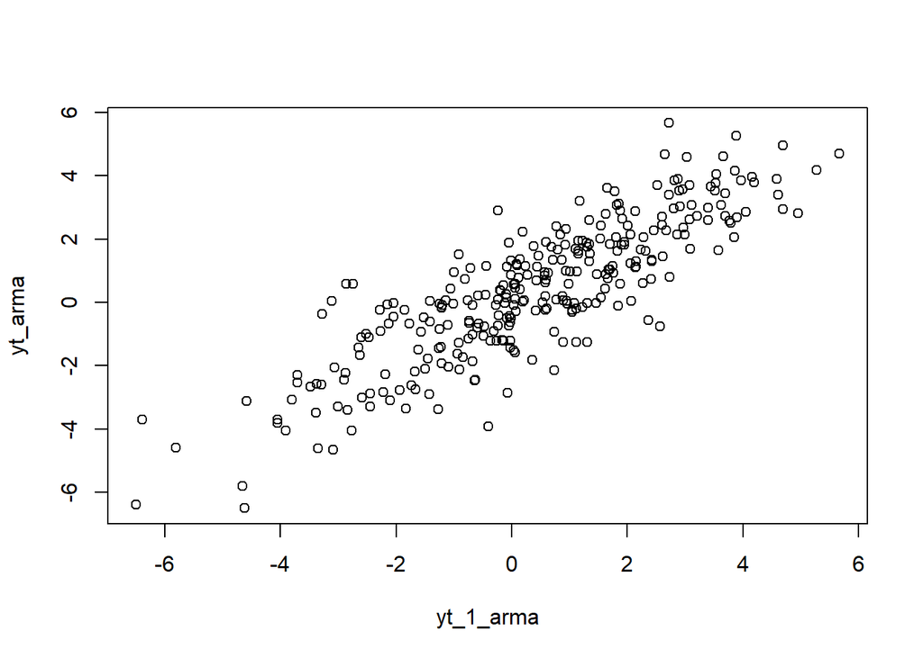

```r
plot(y = yt_arma, x = yt_1_arma)
```

Berdasarkan scatterplot tersebut, terlihat bahwa terdapat hubungan positif antara $Y_t$ dengan $Y_{t-1}$. Hal ini sesuai dengan teori yang ada.

**Nilai Korelasi**

```r
cor(yt_arma, yt_1_arma)
```

```
## [1] 0.8509397
```

#### Korelasi antara $Y_t$ dengan $Y_{t-2}$

```r
# Yt
yt2_arma <- arma22[-c(1, 2)]
yt2_arma
```

```
##   [1] -2.273381915 -0.916144040  1.527794260  2.009389630  2.426420429
##   [6]  1.339657124  1.849435011  3.111095751  3.083766526  3.700992823
##  [11]  3.451775903  3.665285762  4.617780800  3.404702044  2.598722625
##  [16]  2.457606710  2.276869792  2.064956277  0.038786067  0.565471311
##  [21]  0.843446225  2.146055947  1.302822028 -1.260182908 -1.445858632
##  [26] -1.772611717 -0.675488875 -0.092478556  0.141791049  0.418057302
##  [31] -0.258337246 -1.221878356 -1.416441839 -0.599837187 -0.804948085
##  [36]  0.731546288 -2.154626538 -0.073315484 -2.864873253  0.581016158
##  [41] -0.238788143  2.897608271  3.533527182  3.773458320  2.569042031
##  [46] -0.752564045 -1.137968972  0.059737703  0.463552738  1.472821619
##  [51]  0.886583859 -1.250291225 -0.039283211 -0.437791741  1.146938493
##  [56]  1.944790128  1.828322750  1.629835278  2.799516527  2.966203457
##  [61]  2.369554428 -0.570884754 -0.676855728 -1.014147471 -0.043234051
##  [66]  1.877700812  0.584615513  0.186128513  0.030229027 -0.086593618
##  [71]  1.123269634  0.983003070  0.595884455  1.907957571  2.649106037
```

[output cut: 45 more lines]

```r
# Yt-1
yt2_1_arma <- arma22[-c(299, 300)]
yt2_1_arma
```

```
##   [1] -1.678306556 -2.185986827 -2.273381915 -0.916144040  1.527794260
##   [6]  2.009389630  2.426420429  1.339657124  1.849435011  3.111095751
##  [11]  3.083766526  3.700992823  3.451775903  3.665285762  4.617780800
##  [16]  3.404702044  2.598722625  2.457606710  2.276869792  2.064956277
##  [21]  0.038786067  0.565471311  0.843446225  2.146055947  1.302822028
##  [26] -1.260182908 -1.445858632 -1.772611717 -0.675488875 -0.092478556
##  [31]  0.141791049  0.418057302 -0.258337246 -1.221878356 -1.416441839
##  [36] -0.599837187 -0.804948085  0.731546288 -2.154626538 -0.073315484
##  [41] -2.864873253  0.581016158 -0.238788143  2.897608271  3.533527182
##  [46]  3.773458320  2.569042031 -0.752564045 -1.137968972  0.059737703
##  [51]  0.463552738  1.472821619  0.886583859 -1.250291225 -0.039283211
##  [56] -0.437791741  1.146938493  1.944790128  1.828322750  1.629835278
##  [61]  2.799516527  2.966203457  2.369554428 -0.570884754 -0.676855728
##  [66] -1.014147471 -0.043234051  1.877700812  0.584615513  0.186128513
##  [71]  0.030229027 -0.086593618  1.123269634  0.983003070  0.595884455
```

[output cut: 45 more lines]

**Scatter Plot Hubungan Y dan X**

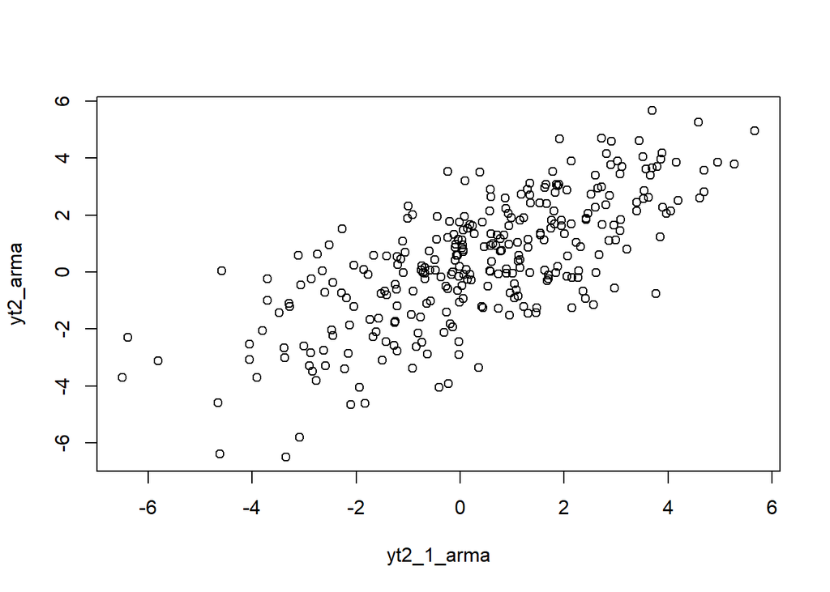

```r
plot(y = yt2_arma, x = yt2_1_arma)
```

**Nilai Korelasi**

```r
cor(yt2_arma, yt2_1_arma)
```

```
## [1] 0.7154872
```

#### Korelasi antara $Y_t$ dengan $Y_{t-3}$

```r
# Yt
yt3_arma <- arma22[-c(1, 2, 3)]
yt3_arma
```

```
##   [1] -0.916144040  1.527794260  2.009389630  2.426420429  1.339657124
##   [6]  1.849435011  3.111095751  3.083766526  3.700992823  3.451775903
##  [11]  3.665285762  4.617780800  3.404702044  2.598722625  2.457606710
##  [16]  2.276869792  2.064956277  0.038786067  0.565471311  0.843446225
##  [21]  2.146055947  1.302822028 -1.260182908 -1.445858632 -1.772611717
##  [26] -0.675488875 -0.092478556  0.141791049  0.418057302 -0.258337246
##  [31] -1.221878356 -1.416441839 -0.599837187 -0.804948085  0.731546288
##  [36] -2.154626538 -0.073315484 -2.864873253  0.581016158 -0.238788143
##  [41]  2.897608271  3.533527182  3.773458320  2.569042031 -0.752564045
##  [46] -1.137968972  0.059737703  0.463552738  1.472821619  0.886583859
##  [51] -1.250291225 -0.039283211 -0.437791741  1.146938493  1.944790128
##  [56]  1.828322750  1.629835278  2.799516527  2.966203457  2.369554428
##  [61] -0.570884754 -0.676855728 -1.014147471 -0.043234051  1.877700812
##  [66]  0.584615513  0.186128513  0.030229027 -0.086593618  1.123269634
##  [71]  0.983003070  0.595884455  1.907957571  2.649106037  4.690579841
```

[output cut: 45 more lines]

```r
# Yt-1
yt3_1_arma <- arma22[-c(298, 299, 300)]
yt3_1_arma
```

```
##   [1] -1.678306556 -2.185986827 -2.273381915 -0.916144040  1.527794260
##   [6]  2.009389630  2.426420429  1.339657124  1.849435011  3.111095751
##  [11]  3.083766526  3.700992823  3.451775903  3.665285762  4.617780800
##  [16]  3.404702044  2.598722625  2.457606710  2.276869792  2.064956277
##  [21]  0.038786067  0.565471311  0.843446225  2.146055947  1.302822028
##  [26] -1.260182908 -1.445858632 -1.772611717 -0.675488875 -0.092478556
##  [31]  0.141791049  0.418057302 -0.258337246 -1.221878356 -1.416441839
##  [36] -0.599837187 -0.804948085  0.731546288 -2.154626538 -0.073315484
##  [41] -2.864873253  0.581016158 -0.238788143  2.897608271  3.533527182
##  [46]  3.773458320  2.569042031 -0.752564045 -1.137968972  0.059737703
##  [51]  0.463552738  1.472821619  0.886583859 -1.250291225 -0.039283211
##  [56] -0.437791741  1.146938493  1.944790128  1.828322750  1.629835278
##  [61]  2.799516527  2.966203457  2.369554428 -0.570884754 -0.676855728
##  [66] -1.014147471 -0.043234051  1.877700812  0.584615513  0.186128513
##  [71]  0.030229027 -0.086593618  1.123269634  0.983003070  0.595884455
```

[output cut: 45 more lines]

**Scatter Plot Hubungan Y dan X**

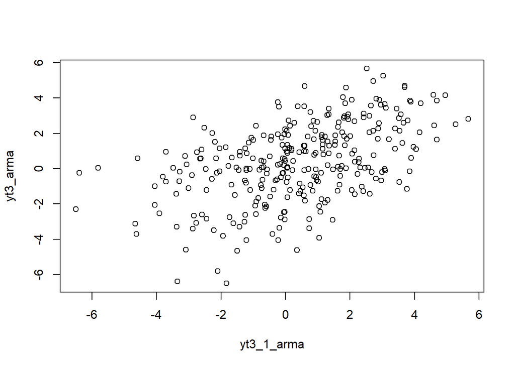

```r
plot(y = yt3_arma, x = yt3_1_arma)
```

**Nilai Korelasi**

```r
cor(yt3_arma, yt3_1_arma)
```

```
## [1] 0.4990599
```